MNIST is a dataset with 70,000, 28x28 pixel, images of handwritten digits that has been called the "Hello World" of machine learning. This is an attempt to build a classifier to predict the digits from images.

Note that this document skips the comparison of performance of different classifier types and instead assumes that KNeighborsClassifier is the best classifier for this task. This is because this is my first attempt at completing a classifier for a classification task.

# Prepare train and test sets

The dataset is readily available to download with Scikit-Learn.

```python
from sklearn.datasets import fetch_mldata
mnist = fetch_mldata('MNIST original')
mnist
```

```
{'COL_NAMES': ['label', 'data'],
 'DESCR': 'mldata.org dataset: mnist-original',
 'data': array([[0, 0, 0, ..., 0, 0, 0],
        [0, 0, 0, ..., 0, 0, 0],
        [0, 0, 0, ..., 0, 0, 0],
        ...,
        [0, 0, 0, ..., 0, 0, 0],
        [0, 0, 0, ..., 0, 0, 0],
        [0, 0, 0, ..., 0, 0, 0]], dtype=uint8),
 'target': array([ 0.,  0.,  0., ...,  9.,  9.,  9.])}
```

Below is an example of what the handwritten digit images look like. It's obviously a 0.

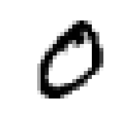

```python
%matplotlib inline
import matplotlib
import matplotlib.pyplot as plt

some_digit = mnist['data'][0] # get a digit to display
some_digit_image = some_digit.reshape(28,28) # reshape array to image matrix

plt.imshow(some_digit_image, cmap = matplotlib.cm.binary)
plt.axis('off') # we just want to view image
plt.show()
```

We can get data and target labels easily.

```python
X, y = mnist['data'], mnist['target']
print(X.shape)
print(y.shape)
```

```
(70000, 784)
(70000,)
```

Normally we would have to do some work to split the dataset into a training and testing to make sure the labels are balanced in both sets (to not end up with only 9 digits in test set etc.). However, the MNIST dataset is already split so that the last 10,000 images are the test set.

```python
X_train, X_test, y_train, y_test = X[:60000], X[60000:], y[:60000], y[60000:]
```

It's often good to shuffle the train set (although it may not be a good option in contexts with time series data).

```python
import numpy as np

shuffle_index = np.random.permutation(60000)
X_train, y_train = X_train[shuffle_index], y_train[shuffle_index]
```

# Train the classifier

Scikit-Learn makes training the K-Neighbors Classifier with the default hyperparameters very easy. We just initialize the classifier and fit it to the training set. We can also check if the classifier can predict the 0 digit displayed previously.

```python
from sklearn.neighbors import KNeighborsClassifier
neigh = KNeighborsClassifier()
neigh.fit(X_train, y_train)
neigh.predict([some_digit])
```

```
array([ 0.])
```

It predicts the digit correctly! Now let's evaluate the performance of the classifier.

# Evaluate classifier performance

We get a fairly high accuracy, almost 97%, measured with cross-validation.

```python
from sklearn.model_selection import cross_val_score
cross_val_score(neigh, X_train, y_train, cv=3, scoring='accuracy')
```

```
array([ 0.96720656,  0.96864843,  0.96659499])
```

We can also measure our performance with a confusion matrix, which gives us more insight into what mistakes our classifier may be making. In the confusion matrix, values along the main diagonal indicate correct predictions. We also need to get a set of predictions to compare with the actual targets as a prerequisite for the confusion matrix.

```python
from sklearn.model_selection import cross_val_predict

y_train_pred = cross_val_predict(neigh, X_train, y_train, cv=3)
```

```python
from sklearn.metrics import confusion_matrix
conf_mx = confusion_matrix(y_train, y_train_pred)
conf_mx
```

```
array([[5879,    4,    5,    0,    1,    5,   24,    2,    1,    2],
       [   1, 6707,   10,    4,    2,    0,    2,   12,    1,    3],
       [  39,   71, 5715,   14,    7,    2,    9,   80,   15,    6],
       [   8,   16,   42, 5900,    0,   59,    3,   39,   37,   27],
       [   4,   56,    2,    1, 5623,    0,   16,   11,    2,  127],
       [  20,   11,    4,   78,    7, 5197,   64,    8,    8,   24],
       [  25,   14,    2,    0,    5,   26, 5844,    0,    2,    0],
       [   4,   68,   16,    2,   16,    1,    0, 6091,    2,   65],
       [  20,   87,   23,   81,   26,  109,   30,   17, 5391,   67],
       [  15,   17,    6,   44,   57,    9,    6,   81,   12, 5702]], dtype=int64)
```

We can visualize the confusion matrix to get feel of the classifier performance more quickly.

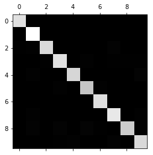

```python
plt.matshow(conf_mx, cmap=plt.cm.gray)
plt.show()
```

From the plot above, it is clear that the classifier is making mostly correct predictions for all numbers. However, because it is so accurate, we can't see what mistakes the classifier is making.

We can make the main diagonal zero to visualize only the error rates.

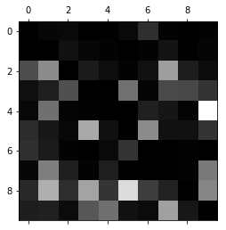

```python
# divide confusion matrix values by number of instances of given class to get error rates rather than absolute number of errors
row_sums = conf_mx.sum(axis=1, keepdims=True)
norm_conf_mx = conf_mx / row_sums

# fill diagonal with 0s because we only want to show error rates
np.fill_diagonal(norm_conf_mx, 0)

# plot confusion matrix
plt.matshow(norm_conf_mx, cmap=plt.cm.gray)
plt.show()
```

From the plot above we can see that the error rates that stand out the most are confusing 4s with 9s and 8s with 5s, which intuitively makes sense as these numbers are relatively similar to each other (especially 4 and 9).

At this point it is good to note that when using the confusion matrix like this, you should double-check what the classes are and how they are ordered in the classifier. In this case, the classes just happen to be conveniently digits 0-9 in order.

```python
neigh.classes_
```

```
array([ 0.,  1.,  2.,  3.,  4.,  5.,  6.,  7.,  8.,  9.])
```

Some other performance measure that are good to look at for classification classifiers are precision, recall and F1 score. Precision measures the accuracy of positive predictions (True Positives/(True Positives + False Positives). Recall/sensitivity/true positive rate measures the ratio of positive instances that are correctly detected by the classifier (True Positives/(True Positives + False Negatives)). There is generally a trade off between precision and recall but a good classifier will have good values in both so the F1 score, which is the harmonic mean of precision and recall, to combine to score of both precision and recall into a single score (2 / (1/precision + 1/recall)).

```python
from sklearn.metrics import precision_score, recall_score, f1_score

precision = precision_score(y_train, y_train_pred, average=None)
recall = recall_score(y_train, y_train_pred, average=None)
f1 = f1_score(y_train, y_train_pred, average=None)

print('precision: {}'.format(precision))
print('recall: {}'.format(recall))
print('F1 score: {}'.format(f1))
```

```
precision: [ 0.97738986  0.95121259  0.98111588  0.9634226   0.97893454  0.96098373
  0.97432477  0.96057404  0.98537744  0.9467043 ]
recall: [ 0.99257133  0.99480866  0.9592145   0.96232262  0.96251284  0.95867921
  0.98749578  0.97222666  0.92138096  0.95848042]
F1 score: [ 0.9849221   0.97252229  0.97004159  0.9628723   0.97065424  0.95983009
  0.98086606  0.96636522  0.95230525  0.95255596]
```

# Data Augmentation

Data augmentation is a technique for artificially growing the training set. In this case, the digit images can be shifted to created a bigger training set (a shifted digits should still represent the original digit).

First we need to create and test our image shifting functions.

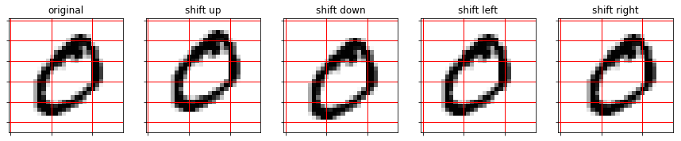

```python
# initialize subplots
fig, ax = plt.subplots(1, 5)
fig.set_figheight(10)
fig.set_figwidth(15)

def shiftUp(digit):
    img = np.append(digit[28:], np.zeros(28, dtype='uint8'))
    return img

def shiftDown(digit):
    img = np.concatenate((np.zeros(28, dtype='uint8'), digit[:756]))
    return img

def shiftLeft(digit):
    def shiftRowLeft(row):
        return np.concatenate((row[1:], np.zeros(1, dtype='uint8')))

    img = digit.reshape(28,28)
    img = np.apply_along_axis(shiftRowLeft, 1, img)
    return img

def shiftRight(digit):
    def shiftRowRight(row):
        return np.concatenate((np.zeros(1, dtype='uint8'), row[:27]))

    img = digit.reshape(28,28)
    img = np.apply_along_axis(shiftRowRight, 1, img)
    return img

# get array with 1 digit to test
digits = mnist['data'][0:1]

# apply shifts to array with 1 digit
shifted_digits_up = np.apply_along_axis(shiftUp, 1, digits)
shifted_digits_down = np.apply_along_axis(shiftDown, 1, digits)
shifted_digits_left = np.apply_along_axis(shiftLeft, 1, digits)
shifted_digits_right = np.apply_along_axis(shiftRight, 1, digits)

# plot original
some_digit_image = digits[0].reshape(28,28) # reshape array to image matrix
ax[0].imshow(some_digit_image, cmap = matplotlib.cm.binary)
ax[0].grid(color='r', linestyle='-', linewidth=1)
ax[0].set_title('original')

# plot up shifted
shifted_digit_up = shifted_digits_up[0].reshape(28, 28) # reshape array to image matrix
ax[1].imshow(shifted_digit_up, cmap = matplotlib.cm.binary)
ax[1].grid(color='r', linestyle='-', linewidth=1)
ax[1].set_title('shift up')

# plot down shifted
shifted_digit_down = shifted_digits_down[0].reshape(28, 28) # reshape array to image matrix
ax[2].imshow(shifted_digit_down, cmap = matplotlib.cm.binary)
ax[2].grid(color='r', linestyle='-', linewidth=1)
ax[2].set_title('shift down')

# plot left shifted
shifted_digit_left = shifted_digits_left[0].reshape(28, 28) # reshape array to image matrix
ax[3].imshow(shifted_digit_left, cmap = matplotlib.cm.binary)
ax[3].grid(color='r', linestyle='-', linewidth=1)
ax[3].set_title('shift left')

#plot right shifted
shifted_digit_right = shifted_digits_right[0].reshape(28, 28) # reshape array to image matrix
ax[4].imshow(shifted_digit_right, cmap = matplotlib.cm.binary)
ax[4].grid(color='r', linestyle='-', linewidth=1)
ax[4].set_title('shift right')

# hide x and y labels
for i in range(5):
    ax[i].xaxis.set_major_formatter(plt.NullFormatter())
    ax[i].yaxis.set_major_formatter(plt.NullFormatter())
```

Once that is done, we can create a reusable function for shifting the images and then apply it on our training set.

```python
def shift_augment(X, y):
    """
    Augment labeled dataset of 28x28 bit images (images as Numpy 1-dimensional arrays) with images shifted in left, right, up and down directions.

    Note that the dataset will grow in size by 400%.
    """

    def shiftImageUp(digit):
        img = np.append(digit[28:], np.zeros(28, dtype='uint8'))
        return img

    def shiftImageDown(digit):
        img = np.concatenate((np.zeros(28, dtype='uint8'), digit[:756]))
        return img

    def shiftImageLeft(digit):
        def shiftRowLeft(row):
            return np.concatenate((row[1:], np.zeros(1, dtype='uint8')))

        img = digit.reshape(28,28)
        img = np.apply_along_axis(shiftRowLeft, 1, img)
        return img.reshape(784)

    def shiftImageRight(digit):
        def shiftRowRight(row):
            return np.concatenate((np.zeros(1, dtype='uint8'), row[:27]))

        img = digit.reshape(28,28)
        img = np.apply_along_axis(shiftRowRight, 1, img)
        return img.reshape(784)

    # shift images in left, right, up and down directions
    X_up_shifted = np.apply_along_axis(shiftImageUp, 1, X)
    X_down_shifted = np.apply_along_axis(shiftImageDown, 1, X)
    X_left_shifted = np.apply_along_axis(shiftImageLeft, 1, X)
    X_right_shifted = np.apply_along_axis(shiftImageRight, 1, X)

    # add shifted images to the feature and target sets
    X_new = np.concatenate((X, X_up_shifted, X_down_shifted, X_left_shifted, X_right_shifted))
    y_new = np.concatenate((y, y, y, y, y))

    # shuffle the result
    shuffle_index = np.random.permutation(y_new.shape[0])
    X_new, y_new = X_new[shuffle_index], y_new[shuffle_index]

    return (X_new, y_new)

# augment training set
X_augmented, y_augmented = shift_augment(X_train, y_train)
print('Original training set size: {}, augmented training set size: {}'.format(y_train.shape[0], y_augmented.shape[0]))
```

```
Original training set size: 60000, augmented training set size: 300000
```

```python
from sklearn.model_selection import cross_val_predict
from sklearn.neighbors import KNeighborsClassifier
from sklearn.metrics import confusion_matrix

neigh_aug = KNeighborsClassifier()
neigh_aug.fit(X_augmented, y_augmented)
```

```
KNeighborsClassifier(algorithm='auto', leaf_size=30, metric='minkowski',
           metric_params=None, n_jobs=1, n_neighbors=5, p=2,
           weights='uniform')
```

Here we run into a problem! Even though the nearest neighbors classifier manages to fit the data within a reasonable time, the predicitions take a very long time. In fact, even after 24 hours, calling the predict function on the classifier below still hasn't completed!

The reason why fitting the training set to the is so fast, is that neighbors classifiers simply store the data from the trainig set. The computational complexity exists mainly in the prediction process because to make each prediction, the classifier has to find the nearest neighbors for the input.

```python
y_augmented_pred = neigh_aug.predict(X_augmented[:60000])
```